# Hayman Fire Recovery

Laney Gordon

February 07, 2022

```r
library(tidyverse)
library(tidyr)
library(ggthemes)
library(lubridate)
library(ggpubr)

# Now that we have learned how to munge (manipulate) data
# and plot it, we will work on using these skills in new ways

knitr::opts_knit$set(root.dir='..')
```

```r
####-----Reading in Data and Stacking it ----- ####
#Reading in files
files <- list.files('data',full.names=T)


#Read in individual data files
ndmi <- read_csv(files[1]) %>%
  rename(burned=2,unburned=3) %>%
  mutate(data='ndmi')


ndsi <- read_csv(files[2]) %>%
  rename(burned=2,unburned=3) %>%
  mutate(data='ndsi')

ndvi <- read_csv(files[3])%>%
  rename(burned=2,unburned=3) %>%
  mutate(data='ndvi')

# Stack as a tidy dataset
full_long <- rbind(ndvi,ndmi,ndsi) %>%
  gather(key='site',value='value',-DateTime,-data) %>%
  filter(!is.na(value))
```

## Question 1)

What is the correlation between NDVI and NDMI? - here I want you to convert the full_long dataset in to a wide dataset using the function “spread” and then make a plot that shows the correlation s a function of if the site was burned or not (x axis should be ndmi) You should exclude winter months and focus on summer months

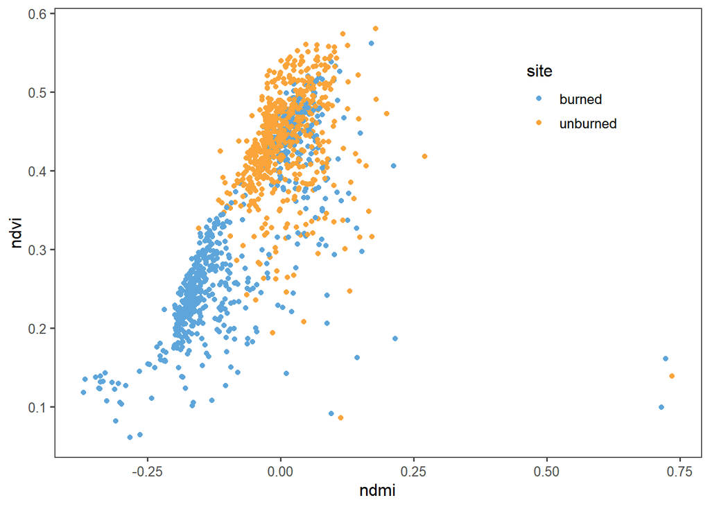

```r
full_wide <- spread(data=full_long,key='data',value='value') %>%
  filter_if(is.numeric,all_vars(!is.na(.))) %>%
  mutate(month = month(DateTime),
         year = year(DateTime))

summer_only <- filter(full_wide,month %in% c(6,7,8,9))

ggplot(summer_only,aes(x=ndmi,y=ndvi,color=site)) +
  geom_point() +
  theme_few() +
  scale_color_few() +
  theme(legend.position=c(0.8,0.8))
```

```r
#correlation
cor(summer_only$ndmi, summer_only$ndvi)
```

```
## [1] 0.6919666
```

Based on the distribution of the plot, and the calculated correlation value, it appears that there is a strong correlation between ndvi and ndmi, however the graph coloring displays that other factors such as burned vs unburned, also effect the outcome of the data.

## Question 2

2. What is the correlation between average NDSI (normalized snow index) for January - April and average NDVI for June-August? In other words, does the previous year’s snow cover influence vegetation growth for the following summer?

```r
ndvi_annual <- full_wide[c(1,2,5,6,7)] %>%
  filter(month %in% c(6,7,8)) %>%
  group_by(site,year) %>%
  summarize(mean_NDVI=mean(ndvi))

ndsi_annual <- full_wide[c(1,2,4,6,7)] %>%
  filter(month %in% c(1,2,3,4)) %>%
  group_by(site,year) %>%
  summarize(mean_NDSI=mean(ndsi))

combinedata <- inner_join(ndvi_annual, ndsi_annual)

cor(combinedata$mean_NDSI, combinedata$mean_NDVI)
```

```
## [1] 0.1803564
```

The correlation coefficient for this data is 0.18, which is close to 0, telling us there is a small correlation between monthly average vegetation index for June through August and monthly average snow index from January to April.

## Q3

How is the snow effect from question 2 different between pre- and post-burn and burned and unburned?

```r
## Pre- and Post- burn
preburn<- c(1984:2001)
postburn <- (2003:2019)

## Preburn
#Preburn annual ndsi
preburn_annualndsi<- full_wide[c(1,2,4,6,7)] %>%
  filter(month %in% c(1,2,3,4)) %>%
  filter(year %in% preburn)%>%
  group_by(site,year) %>%
  summarize(ndsi_preburn_avg=mean(ndsi))

#Preburn annual ndvi
preburn_annualndvi<- full_wide[c(1,2,5,6,7)] %>%
  filter(month %in% c(6,7,8)) %>%
  filter(year %in% preburn)%>%
  group_by(site,year) %>%
  summarize(ndvi_preburn_avg=mean(ndvi))

#combined preburn
combinedPRE<-inner_join(preburn_annualndsi, preburn_annualndvi)

#correlation preburn
cor(combinedPRE$ndsi_preburn_avg, combinedPRE$ndvi_preburn_avg)
```

```
## [1] 0.09100615
```

```r
## Postburn
#Postburn annual ndsi
postburn_annualndsi<- full_wide[c(1,2,4,6,7)] %>%
  filter(month %in% c(1,2,3,4)) %>%
  filter(year %in% postburn)%>%
  group_by(site,year) %>%
  summarize(ndsi_postburn_avg=mean(ndsi))

#Postburn annual ndvi
postburn_annualndvi<- full_wide[c(1,2,5,6,7)] %>%
  filter(month %in% c(6,7,8)) %>%
  filter(year %in% postburn)%>%
  group_by(site,year) %>%
  summarize(ndvi_postburn_avg=mean(ndvi))

#combined postburn
combinedPOST<-inner_join(postburn_annualndsi, postburn_annualndvi)

#correlation postburn
cor(combinedPOST$ndsi_postburn_avg, combinedPOST$ndvi_postburn_avg)
```

```
## [1] 0.24394
```

```r
## Burned vs Unburned
#snow effect average for burned
ndsi_burned_avg<- full_wide[c(1,2,4,6,7)] %>%
  filter(month %in% c(1,2,3,4)) %>%
  filter(site %in% "burned")%>%
  group_by(site,year) %>%
  summarize(ndsi_burned_avg=mean(ndsi))

#vegetation effect average for burned
ndvi_burned_avg<- full_wide[c(1,2,5,6,7)] %>%
  filter(month %in% c(6,7,8)) %>%
  filter(site %in% "burned")%>%
  group_by(site,year) %>%
  summarize(ndvi_burned_avg=mean(ndvi))

#snow effect average for unburned
ndsi_unburned_avg<- full_wide[c(1,2,4,6,7)] %>%
  filter(month %in% c(1,2,3,4)) %>%
  filter(site %in% "unburned")%>%
  group_by(site,year) %>%
  summarize(ndsi_unburned_avg=mean(ndsi))

#vegetation effect average for unburned
ndvi_unburned_avg<- full_wide[c(1,2,5,6,7)] %>%
  filter(month %in% c(6,7,8)) %>%
  filter(site %in% "unburned")%>%
  group_by(site,year) %>%
  summarize(ndvi_unburned_avg=mean(ndvi))


#combining data for burned
combined_burned<-inner_join(ndvi_burned_avg, ndsi_burned_avg)

#combining data for unburned
combined_unburned<-inner_join(ndvi_unburned_avg, ndsi_unburned_avg)

#correlation for burned data
cor(combined_burned$ndvi_burned_avg, combined_burned$ndsi_burned_avg)
```

```
## [1] 0.08700527
```

```r
#correlation for unburned data
cor(combined_unburned$ndvi_unburned_avg, combined_unburned$ndsi_unburned_avg)
```

```
## [1] -0.03100231
```

```r
#graphing the data

Preburngraph<-ggplot(combinedPRE, aes(x=ndsi_preburn_avg, y=ndvi_preburn_avg)) +
  geom_point() +
  theme_few() +
  labs(x= "Average NDSI", y="Average NDVI")
  scale_color_few()
```

[output not shown]

```r
Postburngraph<-ggplot(combinedPOST, aes(x=ndsi_postburn_avg, y=ndvi_postburn_avg)) +
  geom_point() +
  theme_few() +
  labs(x= "Average NDSI", y="Average NDVI")
  scale_color_few()
```

[output not shown]

```r
Burnedgraph<- ggplot(combined_burned, aes(x=ndsi_burned_avg, y=ndvi_burned_avg)) +
  geom_point() +
  theme_few() +
  labs(x= "Average NDSI", y="Average NDVI")
  scale_color_few()
```

[output not shown]

```r
Unburnedgraph<- ggplot(combined_unburned, aes(x=ndsi_unburned_avg, y=ndvi_unburned_avg)) +
  geom_point() +
  theme_few() +
  labs(x= "Average NDSI", y="Average NDVI")
  scale_color_few()
```

[output not shown]

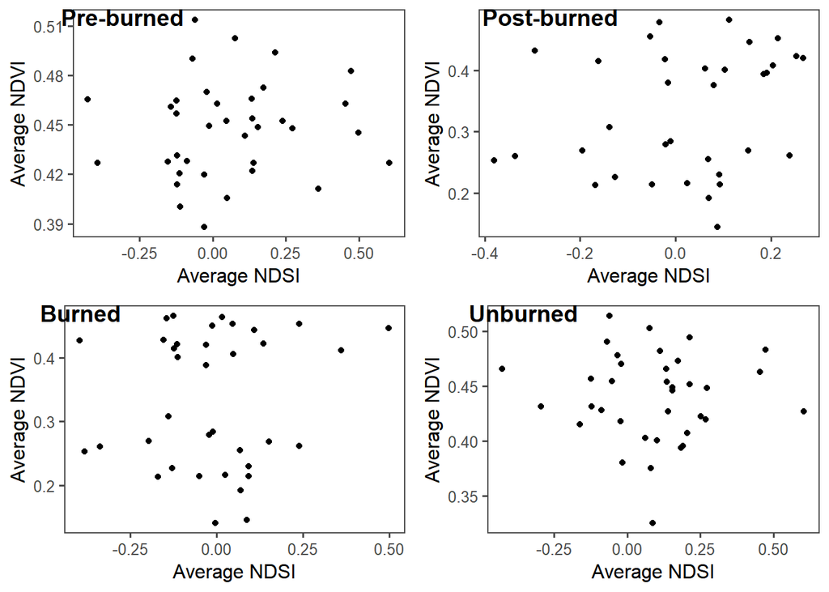

```r
#Plot of data in a single frame
Plot<-ggarrange(Preburngraph, Postburngraph, Burnedgraph, Unburnedgraph,
                labels = c("Pre-burned", "Post-burned", "Burned", "Unburned"),
                ncol = 2, nrow = 2)
Plot
```

It appears that the correlation for postburn is around 0.24 and the correlation for preburn is 0.09, the burned correlation coefficient is about 0.09 and unburned is -0.03. These values tell us that the snow effect across all 4 scenarios have a low correlation. We also see this in our graph, which shows scattered values with some trouble defining a clear pattern.

## Question 4

What month is the greenest month on average?

```r
ndvi_avg_month<- full_wide[c("ndvi", "month")] %>%
  group_by(month) %>%
  summarize(ndvi_avg_month=mean(ndvi))%>%
filter(ndvi_avg_month== max(ndvi_avg_month))

ndvi_avg_month
```

```
## # A tibble: 1 x 2
##   month ndvi_avg_month
##   <dbl>          <dbl>
## 1     8          0.387
```

It appears that the month with the highest vegetation (ndvi) on average occurs in month 8, which is August.

## Question 5)

What month is the snowiest on average?

```r
ndsi_avg_month<- full_wide[c("ndsi", "month")] %>%
  group_by(month) %>%
  summarize(ndsi_avg_month=mean(ndsi))%>%
filter(ndsi_avg_month== max(ndsi_avg_month))

ndsi_avg_month
```

```
## # A tibble: 1 x 2
##   month ndsi_avg_month
##   <dbl>          <dbl>
## 1     1          0.210
```

The month with the highest amount of snow (ndsi) on average occurs in month 1, which is January.

## Bonus Question: Redo all problems with `spread` and `gather` using modern tidyverse syntax.

## Bonus Question: Use Climage Engine to pull the same data for the assignment, but updated with 2020/2021 data.